# Reproducible Research: Peer Assignement 1

Vïctor Rainier Cruz Pérez

11 de agosto de 2014

### Unzip and read the CSV into a raw dataframe:

```r
## Download the url content to a zip file using the online download function (if the web repository its available)
zipfile <- "activity.zip"
if(!file.exists(zipfile)) {
  url <- "https://d396qusza40orc.cloudfront.net/repdata%2Fdata%2Factivity.zip"
  download.file(url, destfile = zipfile, method = "curl", quiet = TRUE)
}
##Unzip the file and Check if it was able to download the file from the web site
unzip(zipfile)
fileflag <- "activity.csv"
if(!file.exists(fileflag)) { stop("It was impossible to download the Zip file from source") }
##Assign the data to a CVS file
ActDownloadedInfo <- read.csv(fileflag)
```

### What is mean total number of steps taken per day?

1. transform the data to aggregate steps by date:

```r
## A Function which it will add by the column date, the steps per day
sumByDtFunct <- function(data, column) {
  dates <- split(data, data$date)
  sapply(dates, function(byDate) {sum(byDate[[column]])})
}
## obtain the mean of each day steps  (Steps column)
dailydata<-sumByDtFunct(ActDownloadedInfo, "steps")
mean(dailydata, na.rm = TRUE)
```

```
## [1] 10766
```

```r
## obtain the median of each day steps
median(dailydata, na.rm = TRUE)
```

```
## [1] 10765
```

Our Data Histogram is:

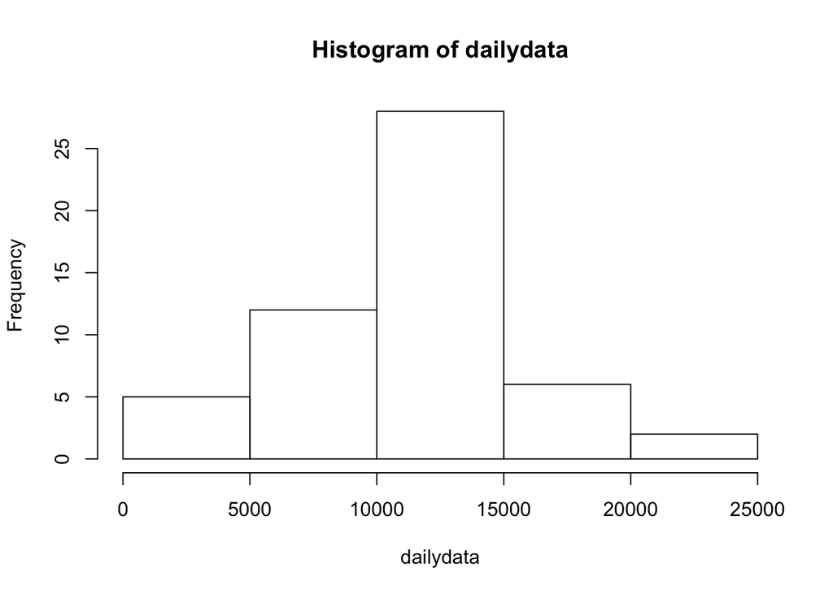

```r
hist(dailydata)
```

### What is the average daily activity pattern?

```r
##Split the Data by intervals
intrvls <- split(ActDownloadedInfo, ActDownloadedInfo$interval)
##Function which determains the mean by step intervals
meanByInterval <- sapply(intrvls, function(byInterval) {mean(byInterval$steps, na.rm = TRUE)})
```

2. Activity by Interval:

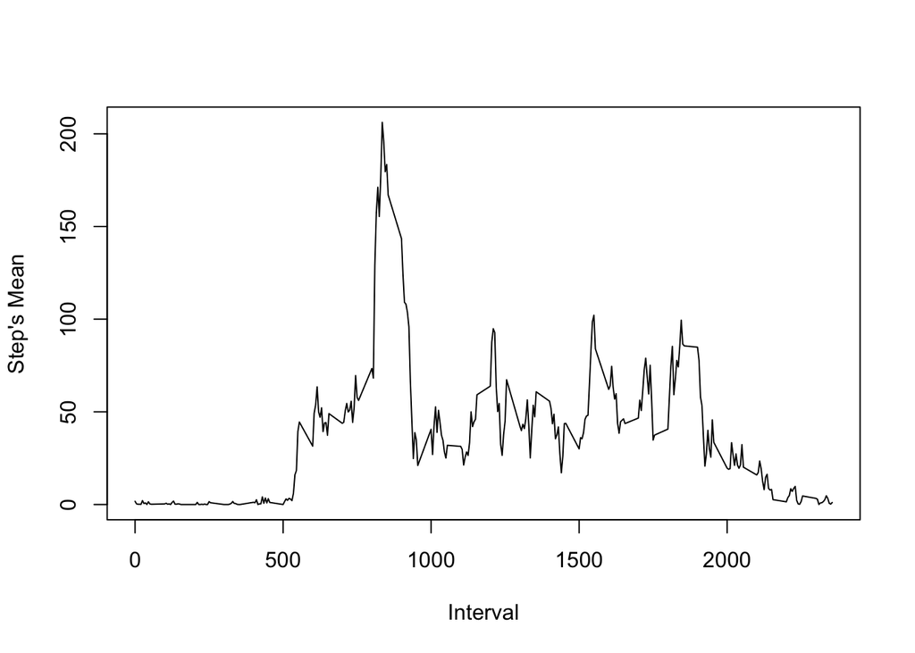

```r
## Trying to know more about the Interval patterns by ploting the data by the interval names
plot(names(meanByInterval), meanByInterval, type='l', xlab = "Interval", ylab = "Step's Mean")
```

3. The interval which has more steps on average is:

```r
as.numeric(names(which.max(meanByInterval)))
```

```
## [1] 835
```

### Imputing missing values

1. Calculating and reporting the total number of missing values in the dataset:

```r
##Counting how many NA values are inside the dataset
sum(is.na(ActDownloadedInfo))
```

```
## [1] 2304
```

Determine the mean by interval considering the NAs values removal across all days:

```r
##determine the mean across all days considering the Na values removal
ActDownloadedInfo$imptSteps <-with(ActDownloadedInfo,ifelse(is.na(steps), meanByInterval[as.character(interval)], steps))
```

Consolidate the Steps by date in aggregated way and show them in an Histogram:

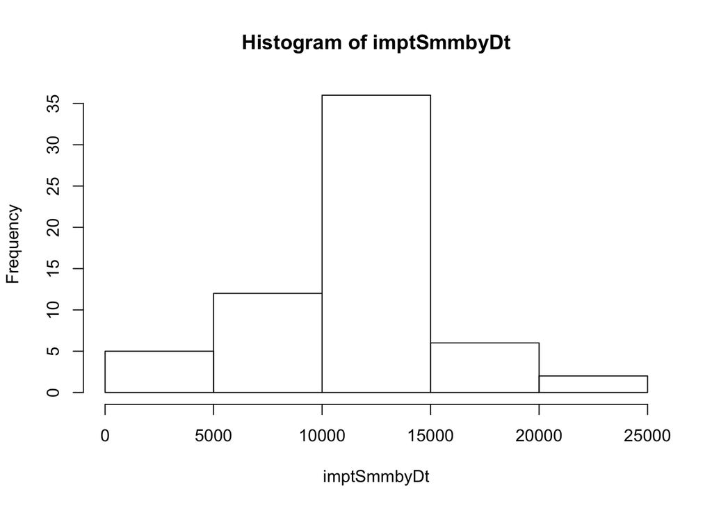

```r
imptSmmbyDt <- sumByDtFunct(ActDownloadedInfo, "imptSteps")
hist(imptSmmbyDt)
```

Determine its median and mean:

```r
## determine the median
median(imptSmmbyDt)
```

```
## [1] 10766
```

```r
## determine the mean
mean(imptSmmbyDt)
```

```
## [1] 10766
```

Base on our findings one can see that the mean is the same no matter if we are considering or not considering the NA values.

In contrast, the median suffered a change. This change mades the median be equal to the mean. This effect is caused by the NA removal that implies no outliers consideration.

### Are there differences in activity patterns between weekdays and weekends?

1. Create a new factor variable in the dataset with two levels: Weekend and Weekdays.
2. Make a panel plot containing a time series plot (i.e. type = “l”) of the 5-minute interval (x-axis) and the average number of steps taken, averaged across all weekday days or weekend days (y-axis).

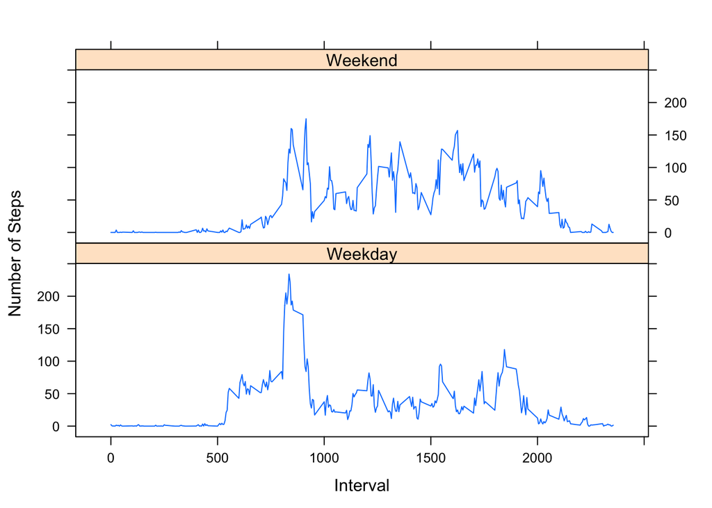

```r
## Agroup the information on Weekend compossed by -Saturday and Sunday- and the weekdays
Dnames <- weekdays(as.POSIXct(ActDownloadedInfo$date))
ActDownloadedInfo$dayType <- ifelse(Dnames %in% c('Saturday', 'Sunday'), 'Weekend', 'Weekday')

## Load the auxiliary Libraries
library(plyr)
library(lattice)

meanByIntrvlandDyTp <- ddply(ActDownloadedInfo, .(interval, dayType),
      function(group) {data.frame(mean = mean(group$steps, na.rm = TRUE))})

with(meanByIntrvlandDyTp, xyplot(mean ~ interval | dayType,
            type = 'l',
            xlab = 'Interval',
            ylab = 'Number of Steps',
            layout = c(1,2)))
```